# Persistence assay analysis

2022-09-30

# Info

Rmarkdown report for the analysis to go with the manuscript “Biofilms preserve the transmissibility of a multi-drug resistance plasmid” by Genevieve A. Metzger, Benjamin J. Ridenhour, Michael France, Karol Gliniewicz, Jack Millstein, Matthew L. Settles, Larry J. Forney, Thibault Stalder, and Eva M. Top.

Data processing steps performed under ‘Data processing’:

1. Model description
2. Import and prepare persistence assays data
3. Persistence assays of evolved clones
1. Persistence assays of the Ancestor and T0
2. Persistence assays of the clones evolved withOUT selection
3. Persistence assays of the clones evolved with selection
4. Persistence assays of truncated and full-length plasmids
1. Persistence assays of evolved plasmids types tested in their co-evolved hosts
2. Persistence assays of evolved plasmids types tested into the ancestral host background

#### Import packages

```r
library(nlme)
library(ggplot2)
#library(RSQLite)
#library(multcomp)
#library(RColorBrewer)
#library(cowplot)
#library(ggpubr)
#library(lemon)
#library(tidyverse)
```

# 1) Model description

Model use is a linear mixed-effects model where the log plasmid:chromosome ratio of each group was predicted using the origin of the clones (i.e., t0, biofilm, or planktonic population) or the type of plasmid tested (i.e., truncated vs full-length) as fixed effect and the clone replicate measure as random effect. Each parameter was nested within the day of the experiment (Days 0, 5, 8) as a continuous variable.

# 2) Import and prepare persistence assays data

```r
#Import the data and prepare for analysis
cNo = read.csv("cNo.csv", header = TRUE, sep = ",")

#Data wrangling
#Attribute Environment, Timepoint, and experimental condition (Experiment) variable to each strains
Environment = c("DOD 77"="Biofilm","DOD 78"="Biofilm","DOD 79"="Biofilm","DOD 228"="Liquid","DOD 230"="Liquid","DOD 232"="Liquid","DOD 71"="Starting", "DOD 72"="Starting", "DOD 73"="Starting","Anc"="Anc","DOD 78-Kingfisher"=NA, "DOD 180"="Liquid", "DOD 74"="Biofilm", "DOD 75"="Biofilm","DOD 76"="Biofilm", "DOD 1487" = "Starting", "DOD 1488" = "Starting", "DOD 1489" = "Starting", "DOD 182"="Liquid", "DOD 184" = "Liquid", "DOD 365.507" = "Transformant", "DOD 370.507" = "Transformant", "DOD 393.507" = "Transformant", "DOD 399.507" = "Transformant", "DOD 405.507" = "Transformant", "DOD 357.776" = "Transformant", "DOD 357.507" = "Transformant", "DOD 1646" = "Biofilm", "DOD 1647" = "Biofilm", "DOD 1592" = "Liquid", "DOD 1648" = "Biofilm", "DOD 1642" = "Liquid", "DOD 1621" = "Liquid", "DOD 357" = "Transformant", "DOD 362" = "Transformant", "DOD 361" = "Transformant")
Timepoint = c("DOD 77"=28,"DOD 78"=28,"DOD 79"=28,"DOD 228"=28,"DOD 230"=28,"DOD 232"=28,"DOD 71"=0, "DOD 72"=0, "DOD 73"=0,"Anc"=-4,"DOD 78-Kingfisher"=NA, "DOD 180"=14, "DOD 74"=14, "DOD 75"=14,"DOD 76"=14, "DOD 1487" = 0, "DOD 1488" = 0, "DOD 1489" = 0, "DOD 182"=14, "DOD 184" = 14, "DOD 365.507" = NA, "DOD 370.507" = NA, "DOD 393.507" = NA, "DOD 399.507" = NA, "DOD 405.507" = NA, "DOD 357.776" = NA, "DOD 357.507" = NA, "DOD 1646" = 14, "DOD 1647" = 14, "DOD 1592" = 6, "DOD 1648" = 14, "DOD 1642" = 14, "DOD 1621" = 10, "DOD 357" = NA, "DOD 362" = NA, "DOD 361" = NA)
Experiment = c("DOD 77"="Abr+","DOD 78"="Abr+","DOD 79"="Abr+","DOD 228"="Abr+","DOD 230"="Abr+","DOD 232"="Abr+","DOD 71"="Abr+", "DOD 72"="Abr+", "DOD 73"="Abr+","Anc"=NA,"DOD 78-Kingfisher"=NA, "DOD 180"="Abr+", "DOD 74"="Abr+", "DOD 75"="Abr+","DOD 76"="Abr+", "DOD 1487" = "Abr-", "DOD 1488" = "Abr-", "DOD 1489" = "Abr-", "DOD 182"="Abr+", "DOD 184" = "Abr+", "DOD 357.507" = NA, "DOD 365.507" = NA, "DOD 370.507" = NA, "DOD 393.507" = NA, "DOD 399.507" = NA, "DOD 405.507" = NA, "DOD 357.776" = NA, "DOD 1646" = "Abr-", "DOD 1647" = "Abr-", "DOD 1592" = "Abr-", "DOD 1648" = "Abr-", "DOD 1642" = "Abr-", "DOD 1621" = "Abr-", "DOD 357" = NA, "DOD 362" = NA, "DOD 361" = NA)

#subset columns
analysisData = cNo[,c("Ancestor","Colony","Day", "ColonyID", "ratio", "ratio.se", "Clone.Number", "Plasmid.size", "mutated")]

#Generate a dataframe with the clones
tempData = data.frame(Ancestor = names(Environment))
tempData$Ancestor = as.character(tempData$Ancestor)
tempData$Environment = Environment[tempData$Ancestor]
tempData$Timepoint = Timepoint[tempData$Ancestor]
tempData$Experiment = Experiment[tempData$Ancestor]
analysisData = merge(analysisData,tempData)
rm(tempData)

#add new environment value that includes Abr status
analysisData$EnvExp = paste(analysisData$Environment, analysisData$Experiment)
analysisData$EnvExp = as.factor(analysisData$EnvExp)
analysisData$EnvExp = relevel(analysisData$EnvExp, ref = "Anc NA")

analysisData$Environment = as.factor(analysisData$Environment)
```

Set up some parameters for graphs

```r
theBreaks = 10^(2:-5*2)
theLabels = c(expression(10^4),expression(10^2),expression(10^0),expression(10^-2),expression(10^-4),expression(10^-6),expression(10^-8),expression(10^10))

theme = theme_classic() +
  theme(legend.text.align = 0) +
  theme(axis.line.x = element_line(colour = 'black', size = 1, linetype = 'solid')) +
  theme(axis.line.y = element_line(colour = 'black', size = 1, linetype = 'solid')) +
  #annotate("text", x = 0, y = 100, label = "A: t0 vs. ancestral strain", size = 5, hjust = 0) +
  theme(legend.text=element_text(size=13))
#ggtitle("A: t0 vs. Ancestral Strain")
```

# 3) Persistence assays of evolved clones

## A) Persistence assays of the Ancestor and T0

- Focus on the ancestor (t-4) and clones isolated from all the biofilms harvested at time t0
- Results show that plasmid persistence dynamics of the ancestor and the T0 were similar.

### Model

```r
#Selected the dataset
analysisData$EnvExp = relevel(analysisData$EnvExp, ref = "Anc NA")
setT0_Anc = analysisData$Environment %in% c("Starting", "Anc") & analysisData$Day %in% c(0,5,8) & analysisData$Timepoint %in% c(-4, 0)

#The model
fullModel.T0_Anc = lme(log(ratio)~Day/EnvExp,random=~1+Day|ColonyID,data=analysisData,subset=setT0_Anc)
vals2_T0_Anc = unique(analysisData[setT0_Anc,c("Day","EnvExp")])
vals2_T0_Anc$predicted = exp(predict(fullModel.T0_Anc, vals2_T0_Anc, level = 0))

summary(fullModel.T0_Anc)
```

```
## Linear mixed-effects model fit by REML
##   Data: analysisData
##   Subset: setT0_Anc
##        AIC      BIC    logLik
##   775.1819 797.8084 -379.5909
##
## Random effects:
##  Formula: ~1 + Day | ColonyID
##  Structure: General positive-definite, Log-Cholesky parametrization
##             StdDev   Corr
## (Intercept) 2.837550 (Intr)
## Day         0.728192 -0.691
## Residual    3.505287
##
## Fixed effects:  log(ratio) ~ Day/EnvExp
##                             Value Std.Error DF   t-value p-value
## (Intercept)             -4.333564 0.6591357 73 -6.574616  0.0000
## Day                     -0.489889 0.6564760 73 -0.746241  0.4579
## Day:EnvExpStarting Abr- -0.429318 0.6633399 73 -0.647206  0.5195
## Day:EnvExpStarting Abr+ -0.253112 0.6629578 73 -0.381793  0.7037
##  Correlation:
##                         (Intr) Day    D:EESA-
## Day                     -0.160
## Day:EnvExpStarting Abr-  0.000 -0.964
## Day:EnvExpStarting Abr+ -0.001 -0.965  0.955
##
## Standardized Within-Group Residuals:
##         Min          Q1         Med          Q3         Max
## -2.72763114 -0.41619235  0.07314478  0.44647555  1.67566484
##
## Number of Observations: 129
## Number of Groups: 53
```

### Plot

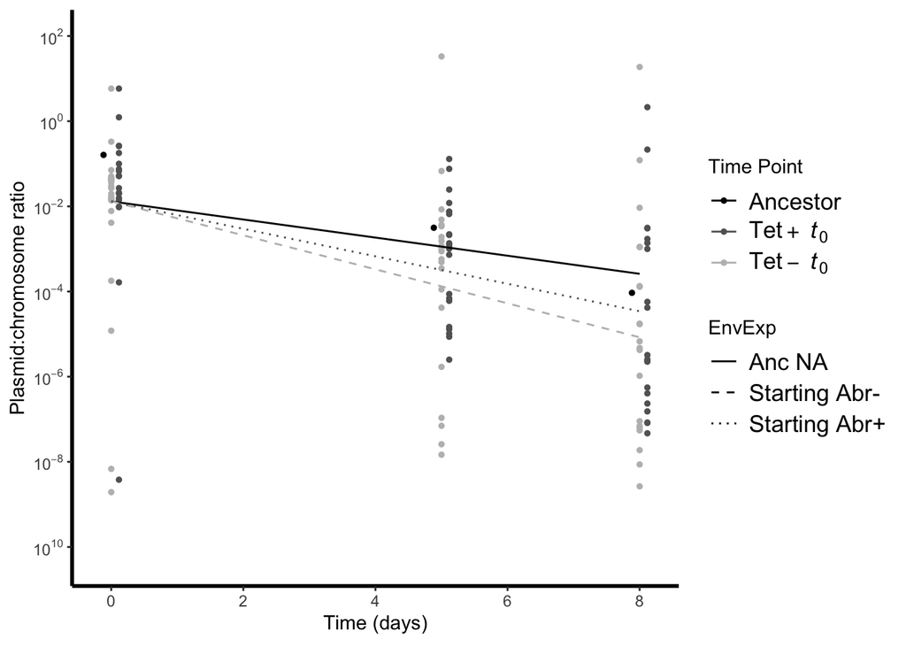

```r
p4_A = ggplot(data=analysisData[setT0_Anc,],aes(x=Day,y=ratio, color=EnvExp))
p4_A = p4_A +
  geom_point(position=position_dodge(w=0.35),size=1) +
  geom_line(data=vals2_T0_Anc,aes(x=Day,y=predicted, color=EnvExp, linetype = EnvExp)) +
  scale_y_continuous(trans = "log10", breaks = theBreaks, labels = theLabels, limits = c(0.00000000005,100)) +
  ylab(expression(paste("Plasmid:chromosome ratio"))) +
  xlab(expression("Time (days)")) +
  scale_color_manual(name="Time Point",
                     breaks=c("Anc NA", "Starting Abr+","Starting Abr-"),
                     labels=c(expression("Ancestor"),
                              expression(Tet+ ~ italic(t)["0"]),
                              expression(Tet- ~ italic(t)["0"])),
                     values=c("#000000","#636363","#bdbdbd")) +
  scale_linetype_manual(values = c("solid", "dashed","dotted")) +
  theme

p4_A
```

## B) Persistence assays of the clones evolved withOUT selection

- Focus on the clones isolated from each time point of the Tet- evolution experiment.
- Results show a drastic increase in plasmid persistence in planktonic populations but not in biofilm populations.

### Model

```r
#Select the dataset
analysisData$Environment = relevel(analysisData$Environment, ref = "Starting")
set5_NS=analysisData$Environment %in% c("Liquid","Biofilm","Starting") & analysisData$Day %in% c(0,5,8) & analysisData$Timepoint %in% c(0,6,10,14) & analysisData$Experiment == "Abr-"


#Model
fullModel.NS = lme(log(ratio)~Day/Environment,random=~1+Day|ColonyID,data=analysisData,subset=set5_NS)
vals2_NS = unique(analysisData[set5_NS,c("Day","Environment")])
vals2_NS$predicted = exp(predict(fullModel.NS, vals2_NS, level = 0))

summary(fullModel.NS)
```

```
## Linear mixed-effects model fit by REML
##   Data: analysisData
##   Subset: set5_NS
##        AIC      BIC    logLik
##   978.6375 1003.724 -481.3187
##
## Random effects:
##  Formula: ~1 + Day | ColonyID
##  Structure: General positive-definite, Log-Cholesky parametrization
##             StdDev    Corr
## (Intercept) 1.8010693 (Intr)
## Day         0.6287891 -0.649
## Residual    2.9247902
##
## Fixed effects:  log(ratio) ~ Day/Environment
##                            Value Std.Error  DF   t-value p-value
## (Intercept)            -4.050858 0.4289692 106 -9.443238  0.0000
## Day                    -0.979864 0.1462821 106 -6.698453  0.0000
## Day:EnvironmentBiofilm  0.233729 0.1855939 106  1.259358  0.2107
## Day:EnvironmentLiquid   0.651742 0.1872072 106  3.481393  0.0007
##  Correlation:
##                        (Intr) Day    Dy:EnB
## Day                    -0.495
## Day:EnvironmentBiofilm -0.005 -0.593
## Day:EnvironmentLiquid  -0.003 -0.589  0.465
##
## Standardized Within-Group Residuals:
##        Min         Q1        Med         Q3        Max
## -3.9487996 -0.2312309  0.1098586  0.3473043  2.0118815
##
## Number of Observations: 174
## Number of Groups: 65
```

### Plot

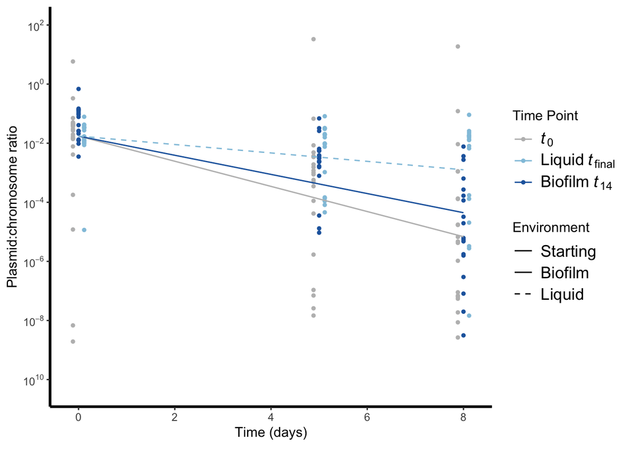

```r
p4_B=ggplot(data=analysisData[set5_NS,],aes(x=Day,y=ratio,colour=Environment))
p4_B=p4_B+
  geom_point(position=position_dodge(w=0.35),size=1)+
  geom_line(data=vals2_NS,aes(x=Day,y=predicted,colour=Environment, linetype = Environment))+
  scale_y_continuous(trans = "log10", breaks = theBreaks, labels = theLabels, limits = c(0.00000000005,100)) +
  ylab(expression(paste("Plasmid:chromosome ratio"))) +
  xlab(expression("Time (days)")) +
  scale_color_manual(name="Time Point",
                     breaks=c("Starting","Liquid","Biofilm"),
                     labels=c(expression(italic(t)["0"]),
                              expression(Liquid ~ italic(t)["final"]),
                              expression(Biofilm ~ italic(t)["14"])),
                     values=c("#bdbdbd", "#92c5de","#2166ac")) +
  scale_linetype_manual(values = c("solid","solid","dashed")) +
  theme

p4_B
```

## C) Persistence assays of the clones evolved with selection

- Focus on clones isolated from each time point of the Tet+ evolution experiment.
- Results show plasmid persistence improved in clones isolated from both biofilm and planktonic populations.

###Model

```r
#subset the dataset
analysisData$Environment = relevel(analysisData$Environment, ref = "Starting")
set10 = analysisData$Environment %in% c("Liquid","Biofilm","Starting") & analysisData$Day %in% c(0,5,8) & analysisData$Timepoint %in% c(0,14) & analysisData$Experiment == "Abr+"

#Model
fullModel.w14 = lme(log(ratio)~Day/Environment,random=~1+Day|ColonyID,data=analysisData,subset=set10)
vals2 = unique(analysisData[set10,c("Day","Environment")])
vals2$predicted = exp(predict(fullModel.w14, vals2, level = 0))
summary(fullModel.w14)
```

```
## Linear mixed-effects model fit by REML
##   Data: analysisData
##   Subset: set10
##        AIC      BIC    logLik
##   898.5736 923.7069 -441.2868
##
## Random effects:
##  Formula: ~1 + Day | ColonyID
##  Structure: General positive-definite, Log-Cholesky parametrization
##             StdDev    Corr
## (Intercept) 1.8958672 (Intr)
## Day         0.5338944 -0.643
## Residual    2.0700084
##
## Fixed effects:  log(ratio) ~ Day/Environment
##                             Value Std.Error  DF   t-value p-value
## (Intercept)            -3.1390186 0.3586520 108 -8.752269  0.0000
## Day                    -0.9428622 0.1159529 108 -8.131426  0.0000
## Day:EnvironmentBiofilm  0.4171710 0.1464557 108  2.848445  0.0053
## Day:EnvironmentLiquid   0.7103169 0.1466931 108  4.842197  0.0000
##  Correlation:
##                        (Intr) Day    Dy:EnB
## Day                    -0.507
## Day:EnvironmentBiofilm  0.003 -0.590
## Day:EnvironmentLiquid   0.007 -0.591  0.465
##
## Standardized Within-Group Residuals:
##         Min          Q1         Med          Q3         Max
## -4.47692708 -0.34629368  0.05597804  0.38928282  2.10788775
##
## Number of Observations: 175
## Number of Groups: 64
```

###Plot

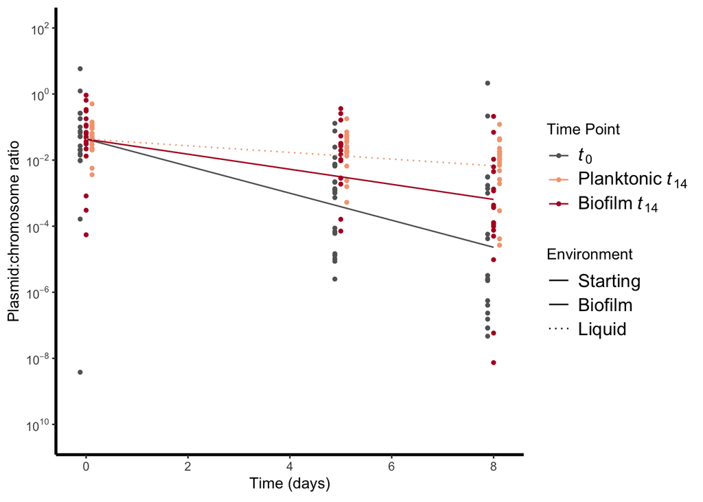

```r
p4_Ct = ggplot(data=analysisData[set10,], aes(x=Day, y=ratio, colour=Environment))
p4_Ct = p4_Ct +
  geom_point(position=position_dodge(w=0.35),size=1) +
  geom_line(data=vals2,aes(x=Day,y=predicted,colour=Environment, linetype = Environment)) +
  scale_y_continuous(trans = "log10", breaks = theBreaks, labels = theLabels, limits = c(0.00000000005,100)) +
  ylab(expression(paste("Plasmid:chromosome ratio"))) +
  xlab(expression("Time (days)")) +
  scale_color_manual(name="Time Point",
                     breaks=c("Starting","Liquid","Biofilm"),
                     labels=c(expression(italic(t)["0"]),
                              expression(Planktonic ~ italic(t)["14"]),
                              expression(Biofilm ~ italic(t)["14"])),
                     values=c("#636363", "#f4a582", "#b2182b")) +
  scale_linetype_manual(values = c("solid","solid", "dotted")) +
  theme

p4_Ct
```

## Generate the figure for the article

```r
#figure = ggarrange(p4_A, p4_B, p4_Ct, ncol = 1, nrow = 3)
#figure = annotate_figure(figure,
#                text_grob("*", y = 0.55, x = 0.5, size = 20),
#                text_grob("]", y = 0.5, x = 0.5, size = 20))

#ggsave(file=paste("./fig_2_v2.pdf"), plot=figure, width=6, height=10)
```

# 4) Persistence assays of truncated and full-length plasmids

## A) Persistence assays of evolved plasmids types tested in their co-evolved hosts

- Focus on the effect of the large plasmid sequence deletions in their co-evolved hosts.
- Results show truncated plasmids had a higher plasmid persistence than clones with full-length plasmids.

```r
set_LDvAvU = analysisData$Environment %in% c("Starting", "Biofilm", "Liquid", "Anc") & analysisData$Day %in% c(0,5,8) & analysisData$Timepoint %in% c(-4, 0, 6, 10, 14, 28) & analysisData$mutated %in% c("anc", "largedel", "unchanged")
```

### Model

```r
analysisData$mutated = factor(analysisData$mutated, level = c("largedel", "anc","unchanged","smalldel","snp"))
fullModel.LDvAvU = lme(log(ratio)~Day/mutated,random=~1+Day|ColonyID,data=analysisData,subset=set_LDvAvU) #control=lmeControl(msMaxIter = 500))
vals2_LDvAvU = unique(analysisData[set_LDvAvU,c("Day","mutated")])
vals2_LDvAvU$predicted = exp(predict(fullModel.LDvAvU, vals2_LDvAvU, level = 0))

summary(fullModel.LDvAvU)
```

```
## Linear mixed-effects model fit by REML
##   Data: analysisData
##   Subset: set_LDvAvU
##        AIC      BIC    logLik
##   2245.398 2277.795 -1114.699
##
## Random effects:
##  Formula: ~1 + Day | ColonyID
##  Structure: General positive-definite, Log-Cholesky parametrization
##             StdDev    Corr
## (Intercept) 2.0097146 (Intr)
## Day         0.5336375 -0.508
## Residual    2.2743107
##
## Fixed effects:  log(ratio) ~ Day/mutated
##                          Value Std.Error  DF    t-value p-value
## (Intercept)          -3.688103 0.2441774 267 -15.104193  0.0000
## Day                  -0.111828 0.0760983 267  -1.469516  0.1429
## Day:mutatedanc       -0.518004 0.5237454 267  -0.989037  0.3235
## Day:mutatedunchanged -0.651228 0.0885950 267  -7.350616  0.0000
##  Correlation:
##                      (Intr) Day    Day:mttdnc
## Day                  -0.452
## Day:mutatedanc        0.000 -0.116
## Day:mutatedunchanged -0.008 -0.680  0.099
##
## Standardized Within-Group Residuals:
##         Min          Q1         Med          Q3         Max
## -4.16152883 -0.23339261  0.05172564  0.34292742  2.41190418
##
## Number of Observations: 428
## Number of Groups: 158
```

### Plot

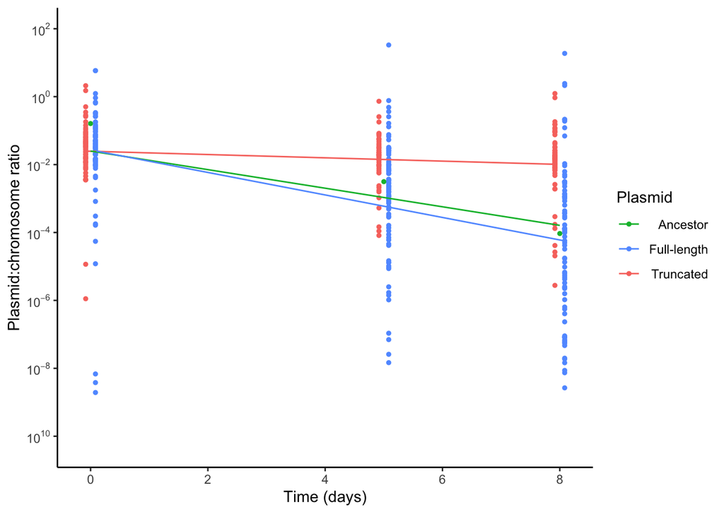

```r
p4_LDvAvU=ggplot(data=analysisData[set_LDvAvU,],aes(x=Day,y=ratio,colour=mutated))
p4_LDvAvU=p4_LDvAvU+geom_point(position=position_dodge(w=0.25),size=1)+
  geom_line(data=vals2_LDvAvU,aes(x=Day,y=predicted,colour=mutated),position=position_dodge(w=0.3))+
  scale_y_continuous(trans = "log10", breaks = theBreaks, labels = theLabels, limits = c(0.00000000005,100)) +
  ylab("Plasmid:chromosome ratio") +
  xlab(expression("Time (days)")) +
  scale_color_discrete(name="Plasmid",
                       breaks=c("anc","unchanged", "largedel"),
                       labels=c(expression("Ancestor"),
                                expression("Full-length"),
                                expression("Truncated")))+
  theme_classic()

p4_LDvAvU
```

## B) Persistence assays of evolved plasmids types tested into the ancestral host background

- Focus on the effect of the large plasmid sequence deletions in the ancestral host background
- Results show that plasmid persistence was higher for the truncated plasmids than for the full-length plasmid or ancestral pB10.

```r
setSizeCompTrans = analysisData$Environment %in% c("Transformant", "Anc") & analysisData$Day %in% c(0,5,8) & analysisData$Clone.Number %in% c("DOD 2198", "DOD 2200", "DOD 2202", "DOD 2204", "DOD 2206", "DOD 67", "DOD 579")
```

###Model

```r
fullModel.TruncTrans = lme(log(ratio)~Day/mutated,random=~1+Day|ColonyID,data=analysisData,subset=setSizeCompTrans, control=lmeControl(msMaxIter = 500))
summary(fullModel.TruncTrans)
```

```
## Linear mixed-effects model fit by REML
##   Data: analysisData
##   Subset: setSizeCompTrans
##        AIC      BIC    logLik
##   92.51094 99.17664 -38.25547
##
## Random effects:
##  Formula: ~1 + Day | ColonyID
##  Structure: General positive-definite, Log-Cholesky parametrization
##             StdDev       Corr
## (Intercept) 2.899531e-05 (Intr)
## Day         5.640459e-06 0
## Residual    1.369028e+00
##
## Fixed effects:  log(ratio) ~ Day/mutated
##                           Value Std.Error DF   t-value p-value
## (Intercept)          -2.7946855 0.4931117 11 -5.667449  0.0001
## Day                  -0.2833253 0.1022384 11 -2.771223  0.0182
## Day:mutatedanc       -0.4664297 0.1622454 11 -2.874841  0.0151
## Day:mutatedunchanged -1.0840672 0.1256747 11 -8.625976  0.0000
##  Correlation:
##                      (Intr) Day    Day:mttdnc
## Day                  -0.705
## Day:mutatedanc        0.000 -0.317
## Day:mutatedunchanged  0.000 -0.410  0.258
##
## Standardized Within-Group Residuals:
##        Min         Q1        Med         Q3        Max
## -2.1143684 -0.6810918  0.2628094  0.6335502  1.6679508
##
## Number of Observations: 21
## Number of Groups: 7
```

```r
vals2_TruncTrans = unique(analysisData[setSizeCompTrans,c("Day","mutated")])
vals2_TruncTrans$predicted = exp(predict(fullModel.TruncTrans, vals2_TruncTrans, level = 0))
```

###plot

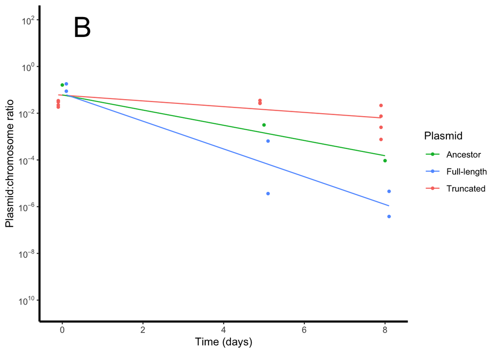

```r
p4_TruncTrans=ggplot(data=analysisData[setSizeCompTrans,],aes(x=Day,y=ratio,colour=mutated))
p4_TruncTrans=p4_TruncTrans+geom_point(position=position_dodge(w=0.3),size=1)+
  geom_line(data=vals2_TruncTrans,aes(x=Day,y=predicted,colour=mutated),position=position_dodge(w=0.3))+
  scale_y_continuous(trans = "log10", breaks = theBreaks, labels = theLabels, limits = c(0.00000000005,100)) +
  ylab("Plasmid:chromosome ratio") +
  xlab(expression("Time (days)")) +
  scale_color_discrete(name="Plasmid",
                       breaks=c("anc","unchanged", "largedel"),
                       labels=c(expression("Ancestor"),
                                expression("Full-length"),
                                expression("Truncated"))) +
  theme_classic()
p4_TruncTrans=p4_TruncTrans+theme(legend.text.align = 0) +
  theme(axis.line.x = element_line(colour = 'black', size = 1, linetype = 'solid')) +
  theme(axis.line.y = element_line(colour = 'black', size = 1, linetype = 'solid')) +
  annotate("text", x = 0.5, y = 50, label = "B", size = 10)
p4_TruncTrans
```

```r
#Combined plot for Truncated comparisons

#plot.4 = plot_grid(p4_LDvAvU, p4_TruncTrans, nrow = 2)

#ggsave(file=paste("./fig_4.pdf"), plot=plot.4, width=6, height=8)
```